# us_president_elections

```python
import warnings
warnings.filterwarnings('ignore')

import os
import re
import pandas as pd
import datetime as dt
import seaborn as sns
import matplotlib.pyplot as plt
from tqdm import tqdm

tqdm.pandas()
sns.set_style("whitegrid")
```

## US President Election Candidate votes by State (1976 - 2016)

```python
df = pd.read_csv('/mnt/d/Quilt/US_DATA/elections/1976-2016-president.csv')
print(df.info())
df.head()
```

```
<class 'pandas.core.frame.DataFrame'>
RangeIndex: 3740 entries, 0 to 3739
Data columns (total 14 columns):
year              3740 non-null int64
state             3740 non-null object
state_po          3740 non-null object
state_fips        3740 non-null int64
state_cen         3740 non-null int64
state_ic          3740 non-null int64
office            3740 non-null object
candidate         3474 non-null object
party             3404 non-null object
writein           3740 non-null bool
candidatevotes    3740 non-null int64
totalvotes        3740 non-null int64
version           3740 non-null int64
notes             0 non-null float64
dtypes: bool(1), float64(1), int64(7), object(5)
memory usage: 383.6+ KB
None
```

|  | year | state | state_po | state_fips | state_cen | state_ic | office | candidate | party | writein | candidatevotes | totalvotes | version | notes |
| --- | --- | --- | --- | --- | --- | --- | --- | --- | --- | --- | --- | --- | --- | --- |
| 0 | 1976 | Alabama | AL | 1 | 63 | 41 | US President | Carter, Jimmy | democrat | False | 659170 | 1182850 | 20171015 | NaN |
| 1 | 1976 | Alabama | AL | 1 | 63 | 41 | US President | Ford, Gerald | republican | False | 504070 | 1182850 | 20171015 | NaN |
| 2 | 1976 | Alabama | AL | 1 | 63 | 41 | US President | Maddox, Lester | american independent party | False | 9198 | 1182850 | 20171015 | NaN |
| 3 | 1976 | Alabama | AL | 1 | 63 | 41 | US President | Bubar, Benjamin ""Ben"" | prohibition | False | 6669 | 1182850 | 20171015 | NaN |
| 4 | 1976 | Alabama | AL | 1 | 63 | 41 | US President | Hall, Gus | communist party use | False | 1954 | 1182850 | 20171015 | NaN |

# Codebook for U.S. President Returns 1976–2016

The data file `1976-2016-president` contains constituency (state-level) returns for elections to the U.S. presidency from 1976 to 2016. The data source is the document "[Statistics of the Congressional Election](http://history.house.gov/Institution/Election-Statistics/Election-Statistics/)," published biennially by the Clerk of the U.S. House of Representatives.

## Variables

The variables are listed as they appear in the data file.

### year

- **Description**: year in which election was held

### office

- **Description**: U.S. President

### state

- **Description**: state name

### state_po

- **Description**: U.S. postal code state abbreviation

### state_fips

- **Description**: State FIPS code

### state_cen

- **Description**: U.S. Census state code

### state_ic

- **Description**: ICPSR state code

### candidate

- **Description**: name of the candidate
- **Note**: The name is as it appears in the House Clerk report.

### party

- **Description**: party of the candidate (always entirely lowercase)
  - **Note**: Parties are as they appear in the House Clerk report. In states that allow candidates to appear on multiple party lines, separate vote totals are indicated for each party. Therefore, for analysis that involves candidate totals, it will be necessary to aggregate across all party lines within a district. For analysis that focuses on two-party vote totals, it will be necessary to account for major party candidates who receive votes under multiple party labels. Minnesota party labels are given as they appear on the Minnesota ballots. Future versions of this file will include codes for candidates who are endorsed by major parties, regardless of the party label under which they receive votes.

### writein

- **Description**: vote totals associated with write-in candidates
- Coding:

[output not shown]

### candidatevotes

- **Description**: votes received by this candidate for this particular party
  - **Note**: Massachusetts and New York returns often contains entries for "blank," "other/blank," "scattering/blank," and the like. For analyses that depend on an accurate count of votes cast for candidates (rather than turnout, including blank ballots), consult state returns. Future versions of this dataset will distinguish blank ballots from votes cast for scattering candidates.

### totalvotes

- **Description**: total number of votes cast for this election

```python
# Deleting columns that are not needed for the analysis.
dropcols = ['state_fips', 'state_cen', 'state_ic', 'office', 'version', 'notes']
df = df.drop(dropcols, 1)
df.head()
```

|  | year | state | state_po | candidate | party | writein | candidatevotes | totalvotes |
| --- | --- | --- | --- | --- | --- | --- | --- | --- |
| 0 | 1976 | Alabama | AL | Carter, Jimmy | democrat | False | 659170 | 1182850 |
| 1 | 1976 | Alabama | AL | Ford, Gerald | republican | False | 504070 | 1182850 |
| 2 | 1976 | Alabama | AL | Maddox, Lester | american independent party | False | 9198 | 1182850 |
| 3 | 1976 | Alabama | AL | Bubar, Benjamin ""Ben"" | prohibition | False | 6669 | 1182850 |
| 4 | 1976 | Alabama | AL | Hall, Gus | communist party use | False | 1954 | 1182850 |

### TOP 10 parties' candidate vote counts by year

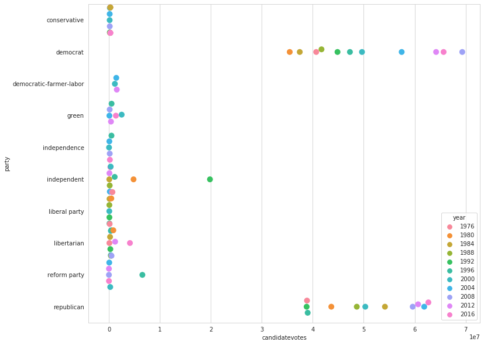

```python
# top 10 parties by total candidate votes in all elections.
parties = (df.groupby('party')
             .agg({'candidatevotes':'sum'})
             .sort_values(by='candidatevotes', ascending=False)
             .head(10).index.values.tolist())
# aggregate candidate votes for each party for each year
data = (df.query(f'party in ({parties})')
          .groupby(['party', 'year'])
          .agg({'candidatevotes':'sum'})
          .reset_index())

plt.figure(figsize=(12, 10))
ax = sns.swarmplot(y="party", x="candidatevotes", hue='year', data=data, size=10)
```

### Total votes growth for all years

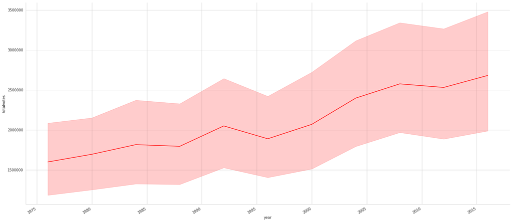

```python
# aggregate candidate votes for each party for each year
data = (df.groupby(['state_po', 'year'])
          .agg({'totalvotes':'min'})
          .reset_index())

ax = sns.relplot(x='year', y='totalvotes', kind='line', data=data, height=10, aspect=2, color='r')
x = ax.fig.autofmt_xdate()
```

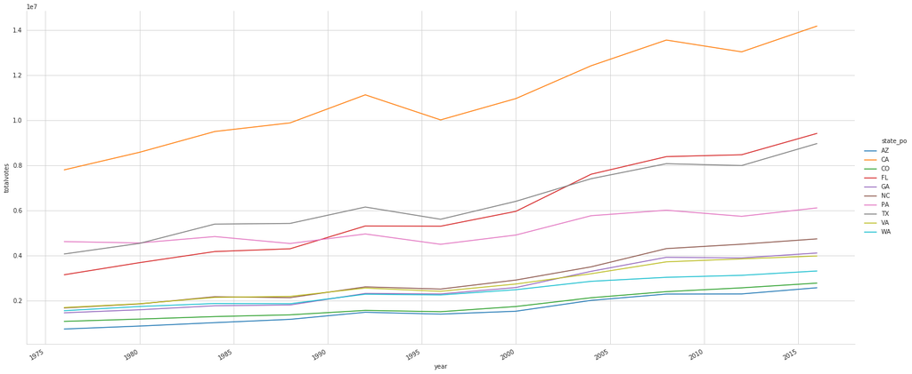

```python
def group_apply(grp):
    grp['diff'] = grp.totalvotes.diff()
    grp['pct_change'] = grp.totalvotes.pct_change()
    return grp

states = (data.query('year in (["1976", "2016"])')
              .groupby('state_po')
              .apply(group_apply)
              .sort_values(by='diff', ascending=False)
              .head(10).state_po.values.tolist())

ax = sns.relplot(x='year', y='totalvotes', hue='state_po', kind='line', data=data.query(f'state_po in ({states})'), height=10, aspect=2, color='r')
x = ax.fig.autofmt_xdate()
```

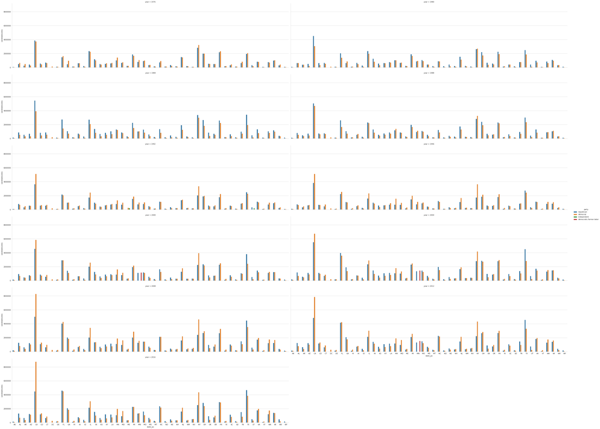

```python
## Fetch top 3 parties for each state for each year.
def grp_apply(grp):
    grp = grp.sort_values(by='candidatevotes', ascending=False).head(2)
    return grp

data = (df.groupby(['year','state_po'])
          .apply(grp_apply)
          .reset_index(drop=True))

ax = sns.catplot(x='state_po', y='candidatevotes', hue='party', data=data, col='year', col_wrap=2, kind='bar', height=6, aspect=4)
```

`Blue - Republicans, Orange - Democrats, Green - Independent, Red - Democratic-farmer-labor`

In the state-wise candidate vote counts for top two parties from 1976-2016, two parties have been the major vote gainers them being Democrat and Republican

In most of the states, both the party candidates have an almost close competition when it comes to vote counts. `Ohio`, `Pennsylvania`, `Florida`, `Virgina`, `West Virginia`, `Wisconsin`, `Georgia` are some of the states that show this trend through out. Democrat or Republican, either of them occasionally getting upper hand in some years.

Another major state `Texas` in the south has been Republican state mostly, especially after 2000.

```python
print(f'List of states: \n{list(df.state.unique())}')
```

[output not shown]

### Fetch top 3 candidates from each year and plot a heatmap of their vote counts

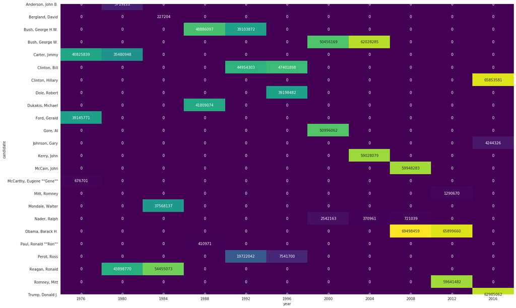

```python
## Fetch top 3 candidates from each year and plot a heatmap of their vote counts
def grp_apply(grp):
    grp = grp.reset_index().sort_values(by='candidatevotes', ascending=False).head(3)
    return grp

data = (df.groupby(['year','candidate'])
          .agg({'candidatevotes':'sum'})
          .groupby(['year'])
          .apply(grp_apply)
          .reset_index(drop=True))

pivot = pd.merge(
    data['year'],
    pd.get_dummies(data.candidate),
    on=data.index
).drop('key_0', 1).set_index('year')

pivot = (pivot.stack()
              .reset_index()
              .rename(columns={'level_1':'candidate'})
              .drop(0, 1))

dmerge = pd.merge(
    pivot,
    data[['year', 'candidate', 'candidatevotes']],
    on=['year', 'candidate'],
    how='left'
).fillna(0)

dmerge['candidatevotes'] = dmerge['candidatevotes'].astype(int)

dmerge = (dmerge.reset_index(drop=True)
                .sort_values(by=['year', 'candidate', 'candidatevotes'], ascending=[1, 1, 0])
                .drop_duplicates()
                .pivot('candidate', 'year', 'candidatevotes'))

# plot the heatmap
plt.figure(figsize=(20, 12))
ax = sns.heatmap(dmerge, annot=True, fmt="d", cmap='viridis', cbar=False)
plt.tight_layout()
```

### top 3 candidates heatmap split by party as well

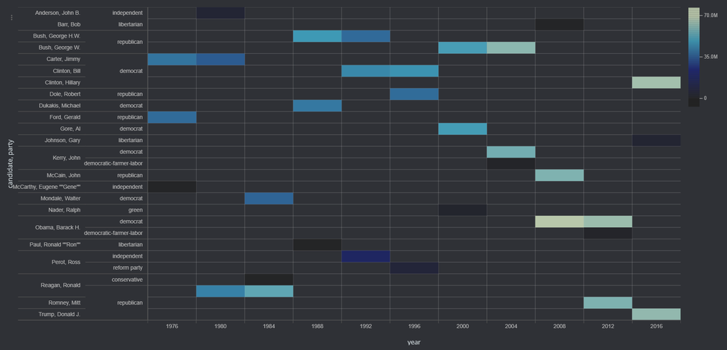

```python
from IPython.display import display, Image
display(Image('/mnt/c/Users/nikhi/Downloads/candidate_by_year.png'))
```

### Writein candidate vote shares each year

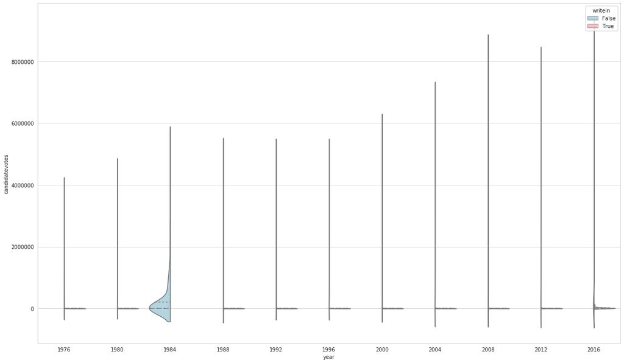

```python
plt.figure(figsize=(20, 12))
ax = sns.violinplot('year', 'candidatevotes', hue='writein', data=df, split=True, inner="quartile", palette=["lightblue", "lightpink"], height=6, aspect=3)
```

### Vote share percentage for the top candidate in each state categorized by year

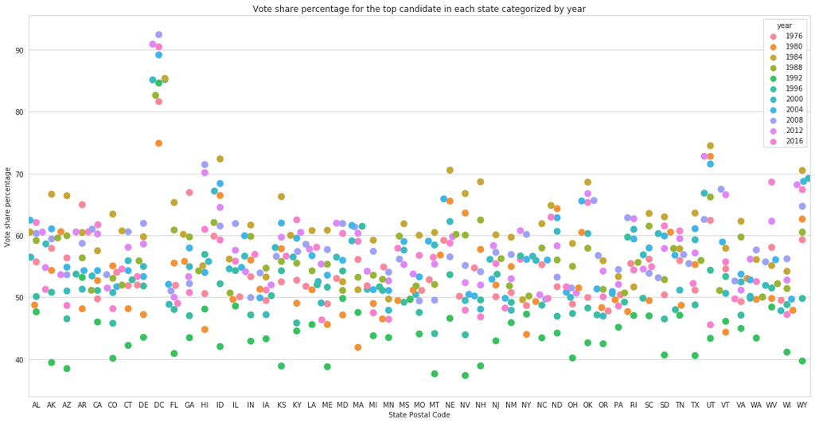

```python
def gapply(grp):
    grp = grp.sort_values(by='candidatevotes', ascending=False).head(1)
    return grp

data = df.groupby(['year', 'state']).apply(gapply).reset_index(drop=True)
data['vshare_prcnt'] = (data.candidatevotes / data.totalvotes) * 100
filtcols = ['year', 'state_po', 'party', 'vshare_prcnt']
# data[filtcols]

# plot the figure
plt.figure(figsize=(20, 10))
ax = sns.swarmplot(x='state_po', y='vshare_prcnt', hue='year', data=data, size=10)
plt.xlabel('State Postal Code')
plt.ylabel('Vote share percentage')
plt.title('Vote share percentage for the top candidate in each state categorized by year')
plt.show()
```

### For all the candidates in all states of all years, plot the relation between candidate votes and total votes.

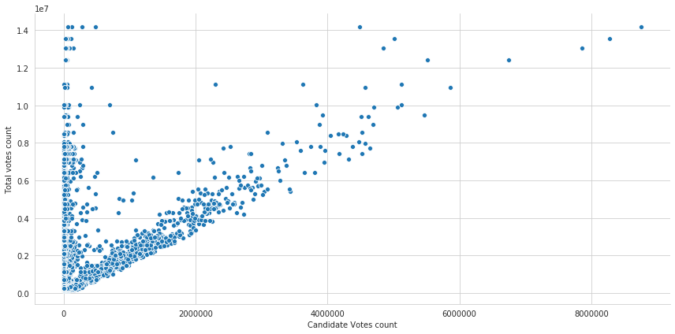

```python
# plot the figure
plt.figure(figsize=(20, 10))
sns.relplot(x="candidatevotes", y="totalvotes", data=df, height=6, aspect=2)
plt.xlabel('Candidate Votes count')
plt.ylabel('Total votes count')
plt.show()
```